# sesion 9

Kimberley Isabel Orozco Cornejo 2023-07-18

# Introducción

En esta sesión, introduciremos el concepto de factor, y aprenderemos el uso de la biblioteca plotly para generar gráficos con más funcionalidades.

## Factores

In R, se utilizan factores para trabajar con variables categóricas, variables que tienen un conjunto fijo y conocido de posibles valores. También son útiles cuando queremos mostrar vectores de caracteres en un orden no alfabético.

Veamos esto con un ejemplo. Supongamos que tenemos un vector con meses como se muestra a continuación:

Si usamos la función class para ver el tipo de vector que tenemos:

```
## [1] "character"
```

vemos que es de tipo carácter. EL uso de una cadena de caracteres para registrar esta variable tiene dos problemas:

1. Solo hay doce meses posibles y nada nos protege de los errores tipográficos:
2. No se ordena de una manera útil (ya que se ordena de manera alfabética)

```
## [1] "Apr" "Dec" "Jan" "Mar"
```

Podemos solucionar ambos problemas con un factor. Para crear un factor, debemos comenzar creando una lista de los niveles válidos:

Ahora podemos crear un factor ordenado:

Si evaluamos ahora la clase de y1:

```
## [1] "ordered" "factor"
```

Vemos que ahora es un factor. Es importante mencionar que no siempre es necesario transformar variables categóricas en factores. En la mayoría de los casos no lo es, sin embargo cuando trabajamos con meses y queremos ordenarlos por ejemplo en gráficos, usar factores ordenados nos puede facilitar muchas cosas.

Por ejemplo, si ahora ordenamos usamos la función sort sobre y1, obtenemos los meses ordenados:

```
## [1] Jan Mar Apr Dec
## Levels: Jan < Feb < Mar < Apr < May < Jun < Jul < Aug < Sep < Oct < Nov < Dec
```

## Lectura de datos

Hoy trabajaremos con un conjunto de datos sobre ventas de propiedades en UK.

[output not shown]

Hagamos una tabla que muestre todas las ventas de propiedades que se dieron en el condado de Buckinghamshire para el año 2008.

Veamos la tabla:

```
## Rows: 2,569
## Columns: 2
## $ District <chr> "AYLESBURY VALE", "SOUTH BUCKS", "AYLESBURY VALE", "WYCOMBE", "WYCOMBE"…
## $ mes      <ord> Jun, Mar, Jun, Oct, Jul, Feb, Apr, Feb, Apr, Sep, Jan, Apr, Dec, Feb, A…
```

## Contrucción de gráfico en ggplot

Recordemos cómo construir un gráfico de barras con ggplot:

Veamos el gráfico sencillo que acabamos de crear:

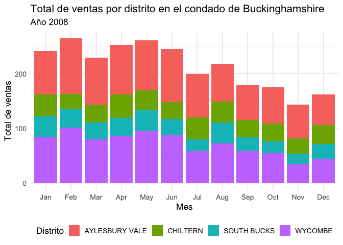

Ahora, añadiremos interactividad con la librería plotly. Para hacerlo, solamente necesitamos pasarle como argumento el gráfico de ggplot que construimos a la función ggplotly, de la siguiente manera:

[output not shown]

[interactive chart not shown]

Observe que esto abrirá el gráfico en nuestro Viewer, y veremos que es un gráfico interactivo, donde podemos observar por ejemplo la cantidad de ventas por distrito, por mes.

Arriba vemos también una barra de herramientas. Si queremos ocultarla, podemos hacerlo así:

[interactive chart not shown]

## Práctica

Utilizando los datos de uk-housing, haga un gráfico de barras que muestre el total de ventas por distrito y mes en el condado de East Sussex para el año 2009. Coloque al gráfico una paleta de colores a su gusto.

## Construcción de gráfico directamente con plot_ly

Empecemos por contruir la tabla que vamos a analizar. En este caso, vamos a crear una tabla que indique los precios promedio y número de ventas por distrito, para los condados de Buckinghamshire, y East Sussex:

Ahora, veamos cómo construir un gráfico directamente con plot_ly:

[interactive chart not shown]

Ok, ¿y si queremos agregar títulos de ejes y formatearlo como deseemos?

[interactive chart not shown]

## Animaciones en un gráfico

Con ggplotly podemos generar gráficos con animaciones interesantes. Empecemos por crear una tabla que queremos visualizar, por ejemplo el número de ventas por distrito y mes en el condado de Buckinghamshire en el año 2008:

Ahora, recordemos la manera de hacer un gráfico de scatter en ggplot:

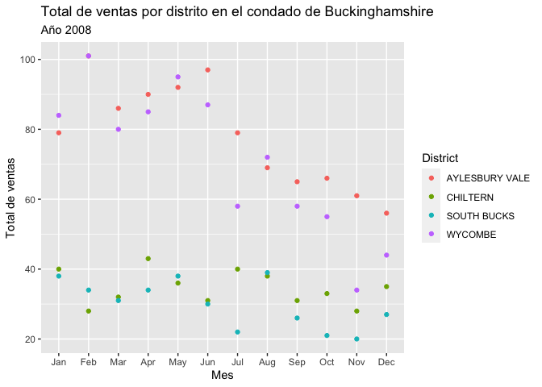

Supongamos ahora que queremos ver una animación de cómo varía el número de ventas con el paso del tiempo, en este caso los meses. Para lograr esto, modificamos un poco el código anterior introduciendo la aes `frame` en geom_point, y colocando el nombre de la variable que tenemos en el eje x:

[interactive chart not shown]

## Práctica

A partir de los datos de UK Housing, obtenga el promedio del precio de las ventas de propiedades por mes, para el año 2008 y el County “East Sussex”. Posteriormente cree una animación con ggplotly que muestre en el eje x los meses, y en el eje y el promedio de precio de las ventas.